# Reproducible Research Assess 1

Clare Wilkinson

Wednesday, March 11, 2015

# Reproducible Research Assessment 1

Set the working directory (note this will be different for everyone)

```r
setwd("~/PhD/Statistics/Cousera courses/Reproducible research/Assessment 1/repdata_data_activity")
```

Load the data

```r
activity_raw <- read.csv('activity.csv', , stringsAsFactors=FALSE)
```

Process the data for your analysis

```r
# Transform the date variable to an actual date format
activity_raw$date <- as.POSIXct(activity_raw$date, format="%Y-%m-%d")

# Compute the weekdays from the date variable
activity_raw <- data.frame(date=activity_raw$date,
                           weekday=tolower(weekdays(activity_raw$date)),
                           steps=activity_raw$steps,
                           interval=activity_raw$interval)

# Compute the type of day (weekend or weekday)
activity_raw <- cbind(activity_raw,
                      daytype=ifelse(activity_raw$weekday == "saturday" |
                                     activity_raw$weekday == "sunday", "weekend",
                                     "weekday"))

# Create the final data.frame
activity <- data.frame(date=activity_raw$date,
                       weekday=activity_raw$weekday,
                       daytype=activity_raw$daytype,
                       interval=activity_raw$interval,
                       steps=activity_raw$steps)

# Remove the raw data set and keep the processed data
rm(activity_raw)

#Display top of table
head(activity)
```

```
##         date weekday daytype interval steps
## 1 2012-10-01  monday weekday        0    NA
## 2 2012-10-01  monday weekday        5    NA
## 3 2012-10-01  monday weekday       10    NA
## 4 2012-10-01  monday weekday       15    NA
## 5 2012-10-01  monday weekday       20    NA
## 6 2012-10-01  monday weekday       25    NA
```

## What is mean total number of steps taken per day? (Ignore the missing values)

1. The number of steps taken per day

```r
# the total number of steps each day (NA values removed)
sumdata <- aggregate(activity$steps, by=list(activity$date), FUN=sum, na.rm=TRUE)

# Rename variable
names(sumdata) <- c("date", "totalsteps")
```

2. a histogram of the total number of steps taken each day

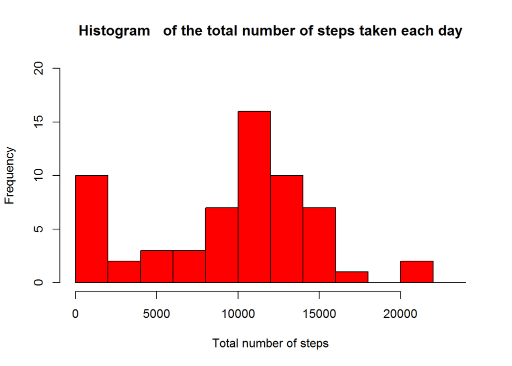

```r
hist(sumdata$totalsteps,  breaks=seq(from=0, to=25000, by=2000), ylim=c(0,20), col="red", xlab="Total number of steps",  main="Histogram   of the total number of steps taken each day")
```

3. The mean and median of the total number of steps taken per day

```r
mean(sumdata$totalsteps)
```

```
## [1] 9354.23
```

```r
median(sumdata$totalsteps)
```

```
## [1] 10395
```